# python程序设计基础2——变量定义，运算，条件与循环

## 有关python软件的安装与使用

- 安装的问题与使用（英文目录，浏览器，notebook替代，ios）
- 请多在qq群里问问题
- 为什么要用winpython——winpython control--模块（包）的概念
- 包的安装：打开WinPython Command Prompt，键入pip install ———— 或者键入：pip install ———— -i http://pypi.douban.com/simple --trusted-host pypi.douban.com
- 有用的包：

https://pypi.python.org/pypi

数据分析——pandas,scikit-learn,matplotlib，bokeh

网络爬虫——beatifulsoup,urllib2,request

科学计算——numpy，scipy

网站架设--django,flask

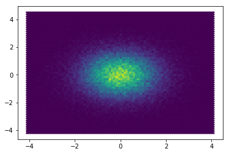

```python
#运行两次？
import pylab
import numpy.random as nr

x=nr.randn(100000)
y=nr.randn(100000)
pylab.hexbin(x,y)
pylab.show()
```

```python
import math
print(math.cos(4))
```

```
-0.6536436208636119
```

## 课后作业

https://github.com/pyecharts/pyecharts-gallery

https://pyecharts.org/#/zh-cn/

请安装如上链接中的包，注意用如下的安装命令：

pip install .... -i http://pypi.douban.com/simple --trusted-host pypi.douban.com

然后运行如下程序，并找到render文件双击打开

```python
#机房电脑暂时还没安装新版本的pyecharts，因此无法运行这里的代码
import pyecharts.options as opts
from pyecharts.charts import WordCloud
name = [
    '阿里巴巴商学院', '数字经济', '马云', '云计算', '微观经济学',
    '天猫', '创业', 'python', '激情', 'Home', '淘宝',
    '云计算', '共享', '电子商务', 'pandas', '梦想',
    '人工智能', '大数据', '商务数据分析', '金融']
value = [4000, 3181, 3386, 3055, 3467, 2244, 2898, 2484, 2112,
    1965, 1847, 1582, 1555, 1550, 1462, 1366, 1360, 1282, 1273, 1065]

data=list(zip(name,value))
```

```python
data
```

```
[('阿里巴巴商学院', 4000),
 ('数字经济', 3181),
 ('马云', 3386),
 ('云计算', 3055),
 ('微观经济学', 3467),
 ('天猫', 2244),
 ('创业', 2898),
 ('python', 2484),
 ('激情', 2112),
 ('Home', 1965),
 ('淘宝', 1847),
 ('云计算', 1582),
 ('共享', 1555),
 ('电子商务', 1550),
 ('pandas', 1462),
 ('梦想', 1366),
 ('人工智能', 1360),
 ('大数据', 1282),
 ('商务数据分析', 1273),
 ('金融', 1065)]
```

```python
WordCloud().add(series_name="商学院视野", data_pair=data, word_size_range=[6, 66]).set_global_opts().render_notebook()
```

# python语法基础

## 一些基本概念与术语：语句，变量，赋值，输出

- 变量命名用字母打头
- 注释标示符

```python
3a1=55
print(a1)
```

```
  File "<ipython-input-9-287aa8cd088d>", line 1
    3a1=55
      ^
SyntaxError: invalid syntax
```

```python
print222=5
```

```python
a=9
print(a)
print(b)
```

```
9
```

```
---------------------------------------------------------------------------
NameError                                 Traceback (most recent call last)
<ipython-input-11-303ae53c7e87> in <module>()
      1 a=9
      2 print(a)
----> 3 print(b)

NameError: name 'b' is not defined
```

```python
5a=5
```

```
  File "<ipython-input-12-e482d97960de>", line 1
    5a=5
     ^
SyntaxError: invalid syntax
```

```python
#看起来不错
a5=6
#print(a5)
```

```python
print1=8
```

## 变量的类型

- 整数（int）,浮点数（float）,字符串（str）
- 不同类型的转换

```python
a="00s"
print(type(a))
```

```
<class 'str'>
```

```python
a="90"
print(type(a))
```

```
<class 'str'>
```

```python
s="9"
print("90"+s)
```

```
909
```

```python
print("40"*4)
```

```
40404040
```

```python
str(9)+"sss"
```

```
'9sss'
```

```python
9+int("4")
```

```
13
```

```python
a=9
print(str(a)+"s")
```

```
9s
```

```python
print("9"+"s")
```

```
9s
```

```python
a="4"
print(int(a)+5)
print(float(a)+5)
```

```
9
9.0
```

## 算术运算：+，-，*，/，%，次方

- 乘法与乘方
- 整除与求余
- 混合运算次序
- 不同类型的变量混合运算

```python
print(17/4,17./4,9%4,3**4)
```

```
4.25 4.25 1 81
```

```python
3-3**2
```

```
-6
```

# 课堂题目

- 求7除以4的余数，求4的5次方，求5除以4，求5.除以4
- 已知两个字符串："a"与"b"，怎样把他们拼接成"ab"？怎样把"a"与数字7拼接起来？

## 逻辑运算：大于，小于，等于（与赋值区分）

```python
#等于需要两个等于号
print(3>2,15<9,2==5,2==2,4!=(5-1),17<=18)
```

```
True False False True False True
```

## if ...else....条件语句与python的语法（程序块的概念）

- if语句的内涵与语法
- 程序块的概念
- python的语法惯例：回撤与冒号
- elif
- and or

```python
a=3
if a!=5 and a<4:
    print("p")
    print("t")
else:
    print("w")
    print("e")
print("t")
```

```
p
t
t
```

```python
a=9
print(a!=4 and a>5, a<8 and a>4, a!=7 or a>4)
```

```
True False True
```

```python
a=2
if a>9:
    print("2")
    print("ee")
else:
    print("1")
    c=a+6
    print(c)
```

```
1
8
```

```python
c=8
if c>9:
    print("w")
elif c>5:
    print("r")
else:
    print("b")
```

```
r
```

```python
c=19
if c>10:print(c)
```

```
19
```

# 课堂题目

- 编程判断89643能否整除3，如果能整除输出“yes”否则“no”
- 编程判断89643能否同时整除3与27，如果能整除输出“yes”否则“no”

[output not shown]

## range函数与循环的概念

- range函数
- 循环的内涵与语法
- 双层循环

```python
for i in range(3,7):
    print(i)
    print(999)
print("kkk")
```

```
3
999
4
999
5
999
6
999
kkk
```

```python
for i in range(1,4):
    for j in range(0,i):
        print(i,j)
    print()
```

```
1 0

2 0
2 1

3 0
3 1
3 2
```

```python
c=1
for i in range(1,5):
    c=c*i
print(c)
```

```
24
```

# 课堂题目

- 编程输出1到100内同时能整除13与2的数

## 循环与累加累乘

```python
a=0
for i in range(0,4):
    a=a+1
print(a)
```

```
4
```

```python
a=0
for i in range(0,4):
    a=a+i
print(a)
```

```
6
```

```python
a=1
for i in range(1,5):
    a=a*i
print(a)
```

```
24
```

```python
a="*"
for i in range(1,5):
    a="*"*i
    print(a)
```

# 课堂题目

```python
#第一题
```

```python
for i in range(1,6):
    print("*")
```

```python
#第二题
```

```python
for i in range(1,6):
    print("*"*i)
```

```python
#第三题
```

```python
for i in range(1,6):
    print(" "*i+"*")
```

```python
#第四题
```

## 输出不换行

- end
- 输出空行

```python
help(print)
```

```
Help on built-in function print in module builtins:

print(...)
    print(value, ..., sep=' ', end='\n', file=sys.stdout, flush=False)

    Prints the values to a stream, or to sys.stdout by default.
    Optional keyword arguments:
    file:  a file-like object (stream); defaults to the current sys.stdout.
    sep:   string inserted between values, default a space.
    end:   string appended after the last value, default a newline.
    flush: whether to forcibly flush the stream.
```

```python
print(2,4,sep="0000")
```

```
200004
```

```python
print(2,4,sep="0000",end="")
print(2,4,sep="0000")
```

```
200004200004
```

```python
for i in range(1,10):
    print(i,end=",")
```

```
1,2,3,4,5,6,7,8,9,
```

# 课堂题目

### 请编程打印如下结果:

```python
# 1
```

```
1
2
3
4
5
6
7
8
9
```

```python
# 2
```

```
1,2,3,4,5,6,7,8,9,
```

```python
# 3
```

```
1 1
1 2
1 3
2 1
2 2
2 3
3 1
3 2
3 3
```

```python
# 4
```

```
1 1 1 2 1 3 2 1 2 2 2 3 3 1 3 2 3 3
```

```python
# 5
```

```
1 1 1 2 1 3
2 1 2 2 2 3
3 1 3 2 3 3
```

```python
# 6
```

```
1 1
2 1 2 2
3 1 3 2 3 3
```

```python
# 7
```

```
1*1=1
2*1=2 2*2=4
3*1=3 3*2=6 3*3=9
4*1=4 4*2=8 4*3=12 4*4=16
5*1=5 5*2=10 5*3=15 5*4=20 5*5=25
6*1=6 6*2=12 6*3=18 6*4=24 6*5=30 6*6=36
7*1=7 7*2=14 7*3=21 7*4=28 7*5=35 7*6=42 7*7=49
8*1=8 8*2=16 8*3=24 8*4=32 8*5=40 8*6=48 8*7=56 8*8=64
9*1=9 9*2=18 9*3=27 9*4=36 9*5=45 9*6=54 9*7=63 9*8=72 9*9=81
```

# 作业

```python
#编程打印如下结果
```

[output not shown]

```python
for i in range(0,6):
    print(" "*(6-i)+"*"+"**"*i)
```

```python
#编程打印如下结果
```

```
1-1
2--2
3---3
4----4
5-----5
6------6
```

```python
for i in range(1,7):
    print(str(i)+"-"*i+str(i))
```

```
1-1
2--2
3---3
4----4
5-----5
6------6
```

- 编程计算1到100内同时能整除13与2的数有多少个？

```python
n=0
for i in range(1,100):
    if i%13==0 and i%2==0:
        n=n+1
print(n)
```

```
3
```